# SoilCarbon

Saki.Wakayama

2026-02-06

*task* est the hypothesis that soil carbon stock (soil.carbon) depends on species richness, altitude, sand cover, annual mean temperature, and precipitation.

```r
library(tidyverse)
data <- read.csv("../Data/FunDivEUROPE.csv")


head(data)
```

```
##   PlotId country annual.mean.temperature annual.mean.precipitation altitude
## 1  FIN01 Finland                     2.6                       625       87
## 2  FIN02 Finland                     2.4                       638      138
## 3  FIN03 Finland                     2.4                       638      139
## 4  FIN04 Finland                     2.5                       637      138
## 5  FIN05 Finland                     2.6                       631      114
## 6  FIN06 Finland                     2.5                       631      112
##   sand soil.depth age.distribution age.canopy.trees target.species.richness
## 1    1         80             even               45                       2
## 2    1         80             even               42                       2
## 3    1         80             even               42                       2
## 4    1         80             even               42                       2
## 5    1         70             even               45                       2
## 6    1         80             even               47                       1
##   species.composition Pielou.evenness prop.conifers tree.biomass.production
```

[output cut: 62 more lines]

```r
str(data)
```

```
## 'data.frame':    208 obs. of  38 variables:
##  $ PlotId                       : chr  "FIN01" "FIN02" "FIN03" "FIN04" ...
##  $ country                      : chr  "Finland" "Finland" "Finland" "Finland" ...
##  $ annual.mean.temperature      : num  2.6 2.4 2.4 2.5 2.6 2.5 2.3 2.3 2.2 2.1 ...
##  $ annual.mean.precipitation    : int  625 638 638 637 631 631 625 624 623 624 ...
##  $ altitude                     : num  87 138 139 138 114 112 120 120 119 134 ...
##  $ sand                         : int  1 1 1 1 1 1 1 1 1 1 ...
##  $ soil.depth                   : int  80 80 80 80 70 80 80 80 80 80 ...
##  $ age.distribution             : chr  "even" "even" "even" "even" ...
##  $ age.canopy.trees             : int  45 42 42 42 45 47 38 38 49 49 ...
##  $ target.species.richness      : int  2 2 2 2 2 1 1 1 1 1 ...
##  $ species.composition          : chr  "Piab.Pisy" "Be.Piab" "Be.Piab" "Be.Piab" ...
##  $ Pielou.evenness              : num  0.543 0.822 0.646 0.948 0.577 ...
##  $ prop.conifers                : num  0.987 0.257 0.165 0.633 0.721 ...
##  $ tree.biomass.production      : num  2.31 1.98 1.49 2.29 1.28 ...
```

[output cut: 24 more lines]

```r
summary(data)
```

```
##     PlotId            country          annual.mean.temperature
##  Length:208         Length:208         Min.   : 1.400
##  Class :character   Class :character   1st Qu.: 5.875
##  Mode  :character   Mode  :character   Median : 7.000
##                                        Mean   : 7.724
##                                        3rd Qu.: 9.700
##                                        Max.   :14.100
##
##  annual.mean.precipitation    altitude           sand         soil.depth
##  Min.   :484.0             Min.   :  87.0   Min.   :1.000   Min.   :20.00
##  1st Qu.:581.0             1st Qu.: 175.0   1st Qu.:1.000   1st Qu.:70.00
##  Median :636.5             Median : 392.5   Median :1.000   Median :80.00
##  Mean   :640.7             Mean   : 526.9   Mean   :1.591   Mean   :66.57
##  3rd Qu.:698.2             3rd Qu.: 869.0   3rd Qu.:2.000   3rd Qu.:80.00
##  Max.   :819.0             Max.   :1404.0   Max.   :3.000   Max.   :80.00
##                                                             NA's   :39
##  age.distribution   age.canopy.trees target.species.richness
##  Length:208         Min.   : 30.00   Min.   :1.000
##  Class :character   1st Qu.: 47.25   1st Qu.:2.000
##  Mode  :character   Median : 70.00   Median :2.000
##                     Mean   : 74.39   Mean   :2.303
##                     3rd Qu.: 87.00   3rd Qu.:3.000
##                     Max.   :700.00   Max.   :5.000
##                     NA's   :98
##  species.composition Pielou.evenness   prop.conifers    tree.biomass.production
##  Length:208          Min.   :0.02182   Min.   :0.0000   Min.   :0.2191
##  Class :character    1st Qu.:0.61640   1st Qu.:0.0000   1st Qu.:1.2465
##  Mode  :character    Median :0.78997   Median :0.2646   Median :1.9132
##                      Mean   :0.71276   Mean   :0.3718   Mean   :2.0080
##                      3rd Qu.:0.93723   3rd Qu.:0.7074   3rd Qu.:2.6086
##                      Max.   :0.99994   Max.   :1.0000   Max.   :5.4161
##                      NA's   :18
##  tree.standing.biomass  root.biomass   leaf.area.index
##  Min.   : 18.88        Min.   :  0.0   Min.   :0.000
##  1st Qu.: 66.99        1st Qu.:103.9   1st Qu.:2.855
##  Median :103.15        Median :150.2   Median :4.550
##  Mean   :115.33        Mean   :155.6   Mean   :4.383
##  3rd Qu.:147.80        3rd Qu.:196.2   3rd Qu.:5.875
##  Max.   :332.14        Max.   :429.9   Max.   :9.100
##                        NA's   :1       NA's   :1
```

[output cut: 49 more lines]

```
##  Min.   :  23.55        Min.   :0.08132      Min.   :-0.008701
##  1st Qu.: 400.86        1st Qu.:0.47954      1st Qu.: 0.234586
##  Median : 540.15        Median :0.70708      Median : 0.356594
##  Mean   : 585.68        Mean   :0.81939      Mean   : 0.401776
##  3rd Qu.: 741.12        3rd Qu.:1.10141      3rd Qu.: 0.505373
##  Max.   :1613.57        Max.   :2.44179      Max.   : 1.397002
##                         NA's   :5
##  soil.CN.ratio
##  Min.   :11.27
##  1st Qu.:15.01
##  Median :17.61
##  Mean   :18.73
##  3rd Qu.:21.18
##  Max.   :40.28
##
```

```r
# check the data tyoe of each predictor

for(var in names(data)){
  cat("Variable:", var, "\n")
  cat("  Class:", class(data[[var]]), "\n")
  cat("  Unique values:", length(unique(data[[var]])), "\n")
  cat("  First 5 values:", head(data[[var]],5), "\n\n")
}
```

```
## Variable: PlotId
##   Class: character
##   Unique values: 208
##   First 5 values: FIN01 FIN02 FIN03 FIN04 FIN05
##
## Variable: country
##   Class: character
##   Unique values: 6
##   First 5 values: Finland Finland Finland Finland Finland
##
## Variable: annual.mean.temperature
##   Class: numeric
##   Unique values: 59
##   First 5 values: 2.6 2.4 2.4 2.5 2.6
##
## Variable: annual.mean.precipitation
##   Class: integer
##   Unique values: 85
##   First 5 values: 625 638 638 637 631
##
## Variable: altitude
##   Class: numeric
##   Unique values: 180
##   First 5 values: 87 138 139 138 114
##
## Variable: sand
##   Class: integer
##   Unique values: 3
##   First 5 values: 1 1 1 1 1
##
## Variable: soil.depth
##   Class: integer
##   Unique values: 6
##   First 5 values: 80 80 80 80 70
##
## Variable: age.distribution
##   Class: character
##   Unique values: 2
##   First 5 values: even even even even even
##
```

[output cut: 134 more lines]

```
##
## Variable: litter.decomposition
##   Class: numeric
##   Unique values: 204
##   First 5 values: 0.5363631 0.5914471 0.5445249 0.8589871 0.6727053
##
## Variable: wood.decomposition
##   Class: numeric
##   Unique values: 208
##   First 5 values: 0.6981472 0.5756892 0.4983935 0.6736443 0.3946927
##
## Variable: soil.CN.ratio
##   Class: numeric
##   Unique values: 208
##   First 5 values: 21.53449 22.01535 20.29999 21.31824 27.33387
```

```r
#with linear regression and check

#transformation to factor of target species richness
data$target.species.richness <- as.factor(data$target.species.richness)
#transformation to factor of sand
data$sand <- as.factor(data$sand)

#try single linear regression and check statistic
lm.soilcarbon.tsr <- lm(soil.carbon ~ target.species.richness, data = data)
lm.soilcarbon.sd  <- lm(soil.carbon ~ sand, data = data)
lm.soilcarbon.altitude <- lm(soil.carbon ~ altitude, data = data)
lm.soilcarbon.temp <- lm(soil.carbon ~ annual.mean.temperature, data = data)
lm.soilcarbon.preci <- lm(soil.carbon ~ annual.mean.precipitation, data = data)
```

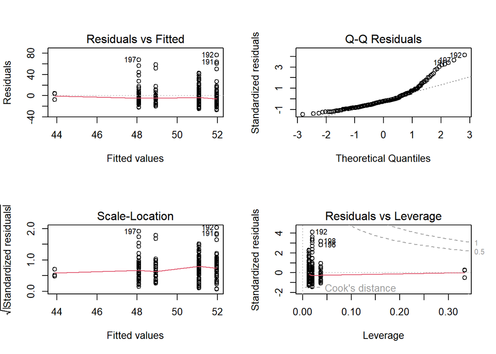

```r
#check model of target species richness
par(mfrow = c(2,2))
plot(lm.soilcarbon.tsr)
```

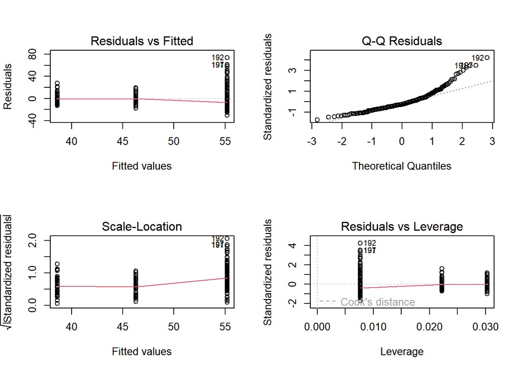

```r
par(mfrow = c(1,1))


# check sd
par(mfrow = c(2,2))
plot(lm.soilcarbon.sd)
```

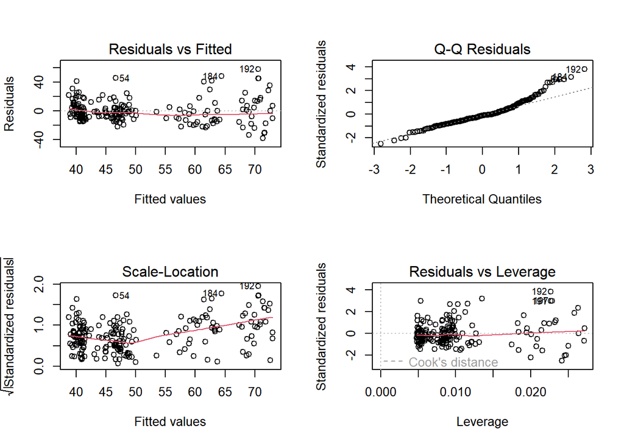

```r
par(mfrow = c(1,1))

#check altitude
par(mfrow = c(2,2))
plot(lm.soilcarbon.altitude)
```

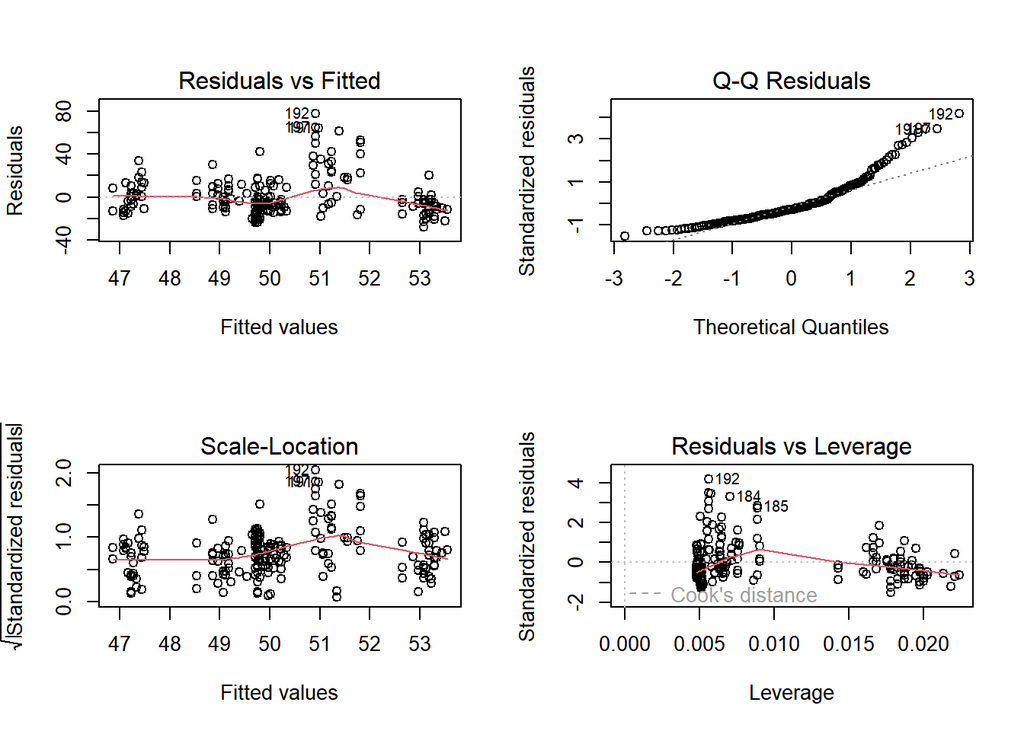

```r
par(mfrow = c(1,1))

#check temp
par(mfrow = c(2,2))
plot(lm.soilcarbon.temp)
```

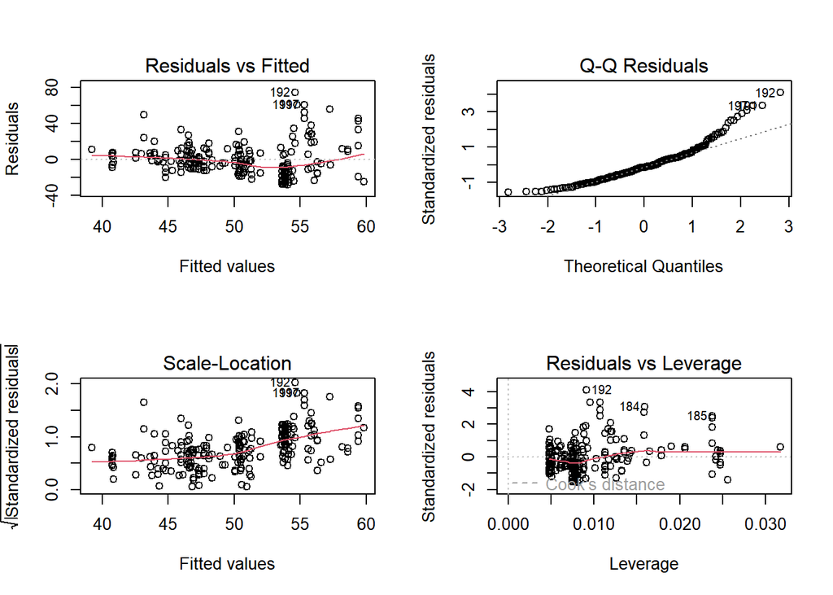

```r
par(mfrow = c(1,1))

#check prici
par(mfrow = c(2,2))
plot(lm.soilcarbon.preci)
```

```r
par(mfrow = c(1,1))
```

```r
#log transformation and try  again lm
min(data$soil.carbon, na.rm = TRUE)
```

```
## [1] 24.94704
```

```r
data$log.soil.carbon <- log(data$soil.carbon)

lm.sc.log.tsr <- lm(log.soil.carbon ~ target.species.richness, data = data)
lm.sc.log.sd  <- lm(log.soil.carbon ~ sand, data = data)
lm.sc.log.altitude <- lm(log.soil.carbon ~ altitude, data = data)
lm.sc.log.temp <- lm(log.soil.carbon ~ annual.mean.temperature, data = data)
lm.sc.log.preci <- lm(log.soil.carbon ~ annual.mean.precipitation, data = data)
```

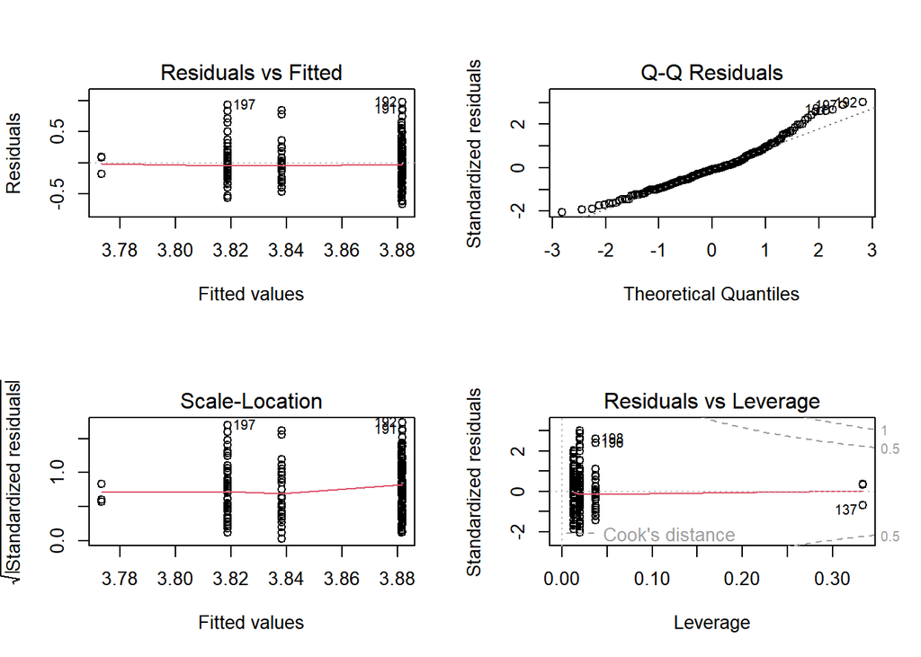

```r
#check model againl with log

#check model of target species richness
par(mfrow = c(2,2))
plot(lm.sc.log.tsr)
```

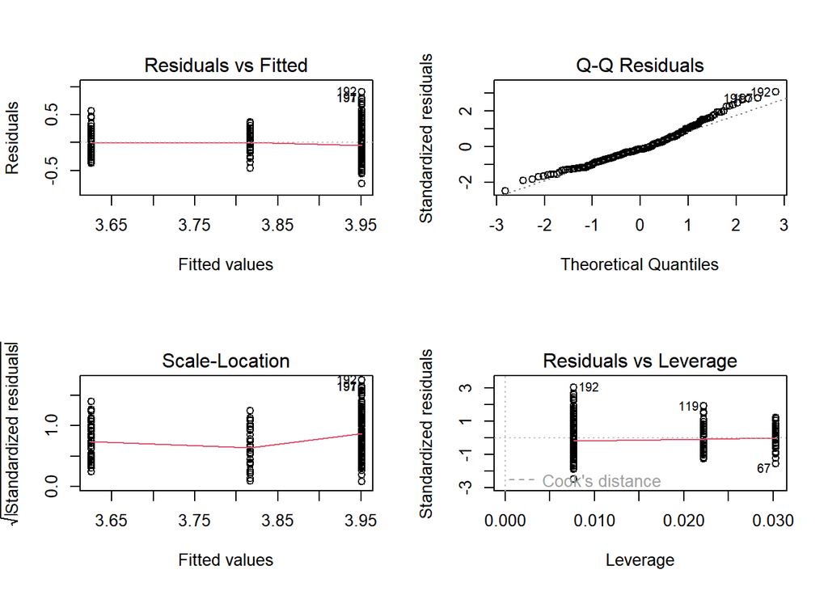

```r
par(mfrow = c(1,1))


# check sd
par(mfrow = c(2,2))
plot(lm.sc.log.sd)
```

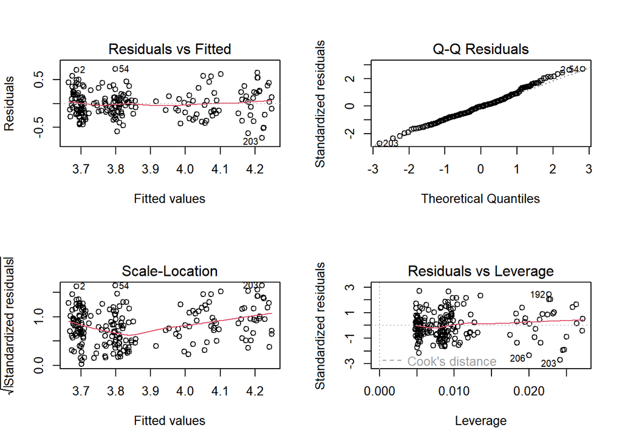

```r
par(mfrow = c(1,1))

#check altitude
par(mfrow = c(2,2))
plot(lm.sc.log.altitude)
```

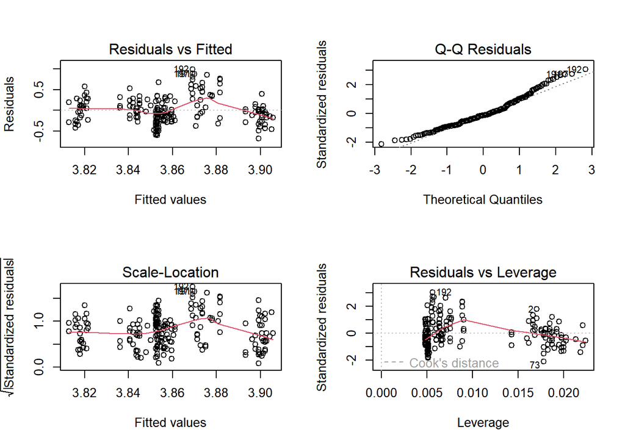

```r
par(mfrow = c(1,1))

#check temp
par(mfrow = c(2,2))
plot(lm.sc.log.temp)
```

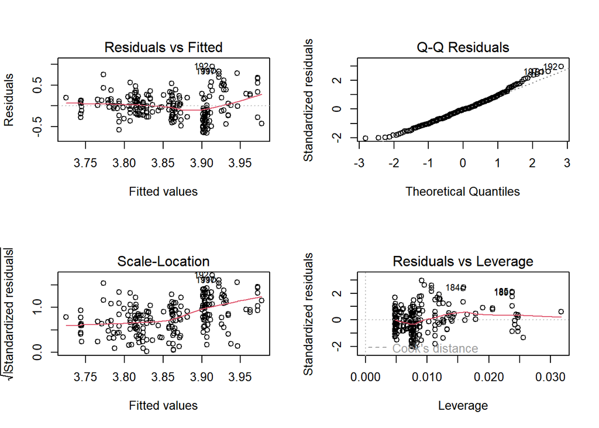

```r
par(mfrow = c(1,1))

#check prici
par(mfrow = c(2,2))
plot(lm.sc.log.preci)
```

```r
par(mfrow = c(1,1))
```

```r
#summary

summary(lm.sc.log.tsr)
```

```
##
## Call:
## lm(formula = log.soil.carbon ~ target.species.richness, data = data)
##
## Residuals:
##      Min       1Q   Median       3Q      Max
## -0.66507 -0.21738 -0.02966  0.18290  0.97621
##
## Coefficients:
##                            Estimate Std. Error t value Pr(>|t|)
## (Intercept)               3.8818226  0.0457860  84.782   <2e-16 ***
## target.species.richness2 -0.0002144  0.0591872  -0.004    0.997
## target.species.richness3 -0.0631079  0.0647511  -0.975    0.331
## target.species.richness4 -0.0434293  0.0778212  -0.558    0.577
## target.species.richness5 -0.1086143  0.1942534  -0.559    0.577
## ---
## Signif. codes:  0 '***' 0.001 '**' 0.01 '*' 0.05 '.' 0.1 ' ' 1
##
## Residual standard error: 0.327 on 203 degrees of freedom
## Multiple R-squared:  0.008303,   Adjusted R-squared:  -0.01124
## F-statistic: 0.4249 on 4 and 203 DF,  p-value: 0.7905
```

The target species richness did not have a significant effect on soil carbon stock (F = 0.425, p = 0.79). The differences in predicted values among the richness levels were also not statistically significant. The overall explanatory power of the model was very low (R² = 0.008), suggesting that most of the variation in soil carbon is dependent on other factors.

```r
summary(lm.sc.log.sd)
```

```
##
## Call:
## lm(formula = log.soil.carbon ~ sand, data = data)
##
## Residuals:
##      Min       1Q   Median       3Q      Max
## -0.73407 -0.20205 -0.04042  0.16360  0.90720
##
## Coefficients:
##             Estimate Std. Error t value Pr(>|t|)
## (Intercept)  3.95083    0.02618 150.888  < 2e-16 ***
## sand2       -0.13447    0.05819  -2.311   0.0218 *
## sand3       -0.32554    0.05164  -6.305 1.74e-09 ***
## ---
## Signif. codes:  0 '***' 0.001 '**' 0.01 '*' 0.05 '.' 0.1 ' ' 1
##
## Residual standard error: 0.2985 on 205 degrees of freedom
## Multiple R-squared:  0.1651, Adjusted R-squared:  0.157
## F-statistic: 20.28 on 2 and 205 DF,  p-value: 9.234e-09
```

The type of sand had a significant effect on soil carbon stock (F = 20.28, p < 0.001). Both sand2 and sand3 had significantly lower soil carbon compared to the reference sand type (sand1). The overall explanatory power of the model was 16%, indicating that sand type accounts for a portion of the variation in soil carbon.

```r
summary(lm.sc.log.altitude)
```

```
##
## Call:
## lm(formula = log.soil.carbon ~ altitude, data = data)
##
## Residuals:
##      Min       1Q   Median       3Q      Max
## -0.72330 -0.18621 -0.00731  0.15802  0.72762
##
## Coefficients:
##              Estimate Std. Error t value Pr(>|t|)
## (Intercept) 3.625e+00  3.074e-02 117.941   <2e-16 ***
## altitude    4.435e-04  4.618e-05   9.603   <2e-16 ***
## ---
## Signif. codes:  0 '***' 0.001 '**' 0.01 '*' 0.05 '.' 0.1 ' ' 1
##
## Residual standard error: 0.2709 on 206 degrees of freedom
## Multiple R-squared:  0.3092, Adjusted R-squared:  0.3059
## F-statistic: 92.21 on 1 and 206 DF,  p-value: < 2.2e-16
```

Altitude had a significant positive effect on soil carbon stock (F = 92.21, p < 0.001), with soil carbon increasing as altitude rises. The overall explanatory power of the model was approximately 31%, indicating that altitude accounts for a portion of the variation in soil carbon.

```r
summary(lm.sc.log.temp)
```

```
##
## Call:
## lm(formula = log.soil.carbon ~ annual.mean.temperature, data = data)
##
## Residuals:
##      Min       1Q   Median       3Q      Max
## -0.68244 -0.23637 -0.04327  0.18839  0.98888
##
## Coefficients:
##                         Estimate Std. Error t value Pr(>|t|)
## (Intercept)             3.802471   0.056850  66.886   <2e-16 ***
## annual.mean.temperature 0.007328   0.006758   1.084    0.279
## ---
## Signif. codes:  0 '***' 0.001 '**' 0.01 '*' 0.05 '.' 0.1 ' ' 1
##
## Residual standard error: 0.325 on 206 degrees of freedom
## Multiple R-squared:  0.005676,   Adjusted R-squared:  0.0008489
## F-statistic: 1.176 on 1 and 206 DF,  p-value: 0.2795
```

Annual mean temperature did not have a significant effect on soil carbon stock on its own (F = 1.176, p = 0.28). The overall explanatory power of the model was minimal (R² ≈ 0.006), indicating that variation in soil carbon cannot be explained by temperature alone.

```r
summary(lm.sc.log.preci)
```

```
##
## Call:
## lm(formula = log.soil.carbon ~ annual.mean.precipitation, data = data)
##
## Residuals:
##      Min       1Q   Median       3Q      Max
## -0.65144 -0.21954 -0.00894  0.18854  0.94476
##
## Coefficients:
##                             Estimate Std. Error t value Pr(>|t|)
## (Intercept)                4.3435781  0.1904715  22.804   <2e-16 ***
## annual.mean.precipitation -0.0007563  0.0002953  -2.561   0.0111 *
## ---
## Signif. codes:  0 '***' 0.001 '**' 0.01 '*' 0.05 '.' 0.1 ' ' 1
##
## Residual standard error: 0.3209 on 206 degrees of freedom
## Multiple R-squared:  0.03086,    Adjusted R-squared:  0.02616
## F-statistic:  6.56 on 1 and 206 DF,  p-value: 0.01114
```

Annual mean precipitation had a small but significant negative effect on soil carbon stock (β = -0.00076, p = 0.011). The overall explanatory power of the model was low (R² ≈ 0.03), indicating that precipitation alone cannot account for most of the variation in soil carbon.

Based on the results so far, species richness, temperature, and precipitation cannot be considered as primary explanatory variables for soil carbon on their own. In contrast, altitude and sand type appear to have the potential to act as major single factors influencing soil carbon. Therefore, a base model using altitude and sand as fixed effects should first be constructed, and the distribution of the residuals should be re-examined. After that, models incorporating interaction effects and random effects can be created, visualized, and tested separately.

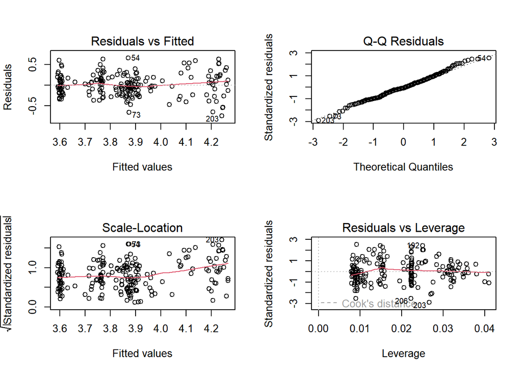

```r
# sand, atitude model

lm.sd.at <- lm(log.soil.carbon ~ sand + altitude, data = data)

par(mfrow = c(2, 2))
plot(lm.sd.at)
```

```r
summary(lm.sd.at)
```

```
##
## Call:
## lm(formula = log.soil.carbon ~ sand + altitude, data = data)
##
## Residuals:
##      Min       1Q   Median       3Q      Max
## -0.74542 -0.17410 -0.02034  0.15815  0.65655
##
## Coefficients:
##               Estimate Std. Error t value Pr(>|t|)
## (Intercept)  3.717e+00  3.664e-02 101.447  < 2e-16 ***
## sand2       -1.563e-01  5.072e-02  -3.082 0.002342 **
## sand3       -1.817e-01  4.827e-02  -3.764 0.000218 ***
## altitude     3.920e-04  4.802e-05   8.163 3.34e-14 ***
## ---
## Signif. codes:  0 '***' 0.001 '**' 0.01 '*' 0.05 '.' 0.1 ' ' 1
##
## Residual standard error: 0.2598 on 204 degrees of freedom
## Multiple R-squared:  0.3707, Adjusted R-squared:  0.3614
## F-statistic: 40.06 on 3 and 204 DF,  p-value: < 2.2e-16
```

```r
lm.sd.at.int <- lm(log.soil.carbon ~ sand * altitude, data = data)
anova(lm.sd.at, lm.sd.at.int)
```

```
## Analysis of Variance Table
##
## Model 1: log.soil.carbon ~ sand + altitude
## Model 2: log.soil.carbon ~ sand * altitude
##   Res.Df    RSS Df Sum of Sq      F Pr(>F)
## 1    204 13.772
## 2    202 13.746  2  0.026088 0.1917 0.8257
```

No interaction was detected between sand and altitude. Adding the sand × altitude interaction to the model did not significantly improve it (F = 0.192, p = 0.826). Therefore, the effects of sand and altitude on soil carbon stock can be adequately explained by their main effects alone.

```r
#about precipitation
lm.base <- lm(log.soil.carbon ~ sand + altitude, data = data)
lm.p <- lm(log.soil.carbon ~ sand + altitude + annual.mean.precipitation, data = data)
anova(lm.base, lm.p)
```

```
## Analysis of Variance Table
##
## Model 1: log.soil.carbon ~ sand + altitude
## Model 2: log.soil.carbon ~ sand + altitude + annual.mean.precipitation
##   Res.Df    RSS Df Sum of Sq      F  Pr(>F)
## 1    204 13.772
## 2    203 13.521  1   0.25129 3.7727 0.05348 .
## ---
## Signif. codes:  0 '***' 0.001 '**' 0.01 '*' 0.05 '.' 0.1 ' ' 1
```

The effect of annual mean precipitation on soil carbon is only marginally significant, but considering potential influences of random effects, it will be retained as a fixed effect.

Step 1: Visualization of the Base Model with Fixed Effects

The fixed effects to be included are:

Sand (categorical variable)

Altitude (continuous variable)

Annual mean precipitation (continuous variable)

This base model will allow us to visualize the relationships of these key predictors with soil carbon before adding interaction or random effects.

```r
library(effects)
```

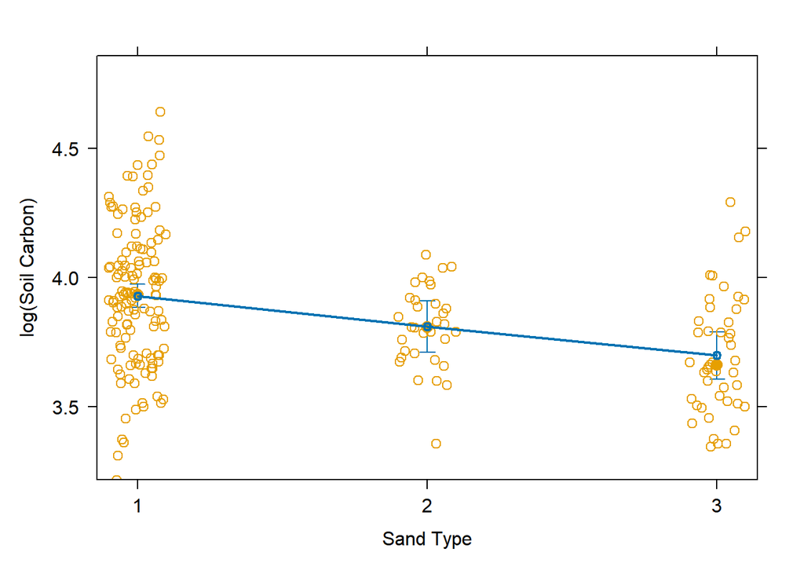

```r
m_base <- lm(log.soil.carbon ~ sand + altitude + annual.mean.precipitation, data = data)


eff_sand <- effect("sand", m_base, partial.residuals = TRUE)


plot(eff_sand,
     main = "",
     ylab = "log(Soil Carbon)",
     xlab = "Sand Type")
```

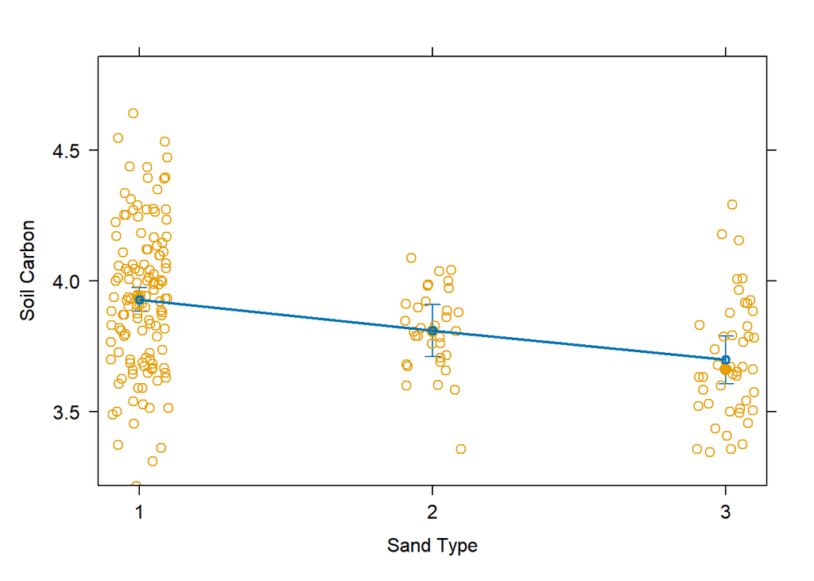

```r
plot(eff_sand,
     main = "",
     ylab = "Soil Carbon",
     xlab = "Sand Type",
     transformation = list(link = log, inverse = exp))
```

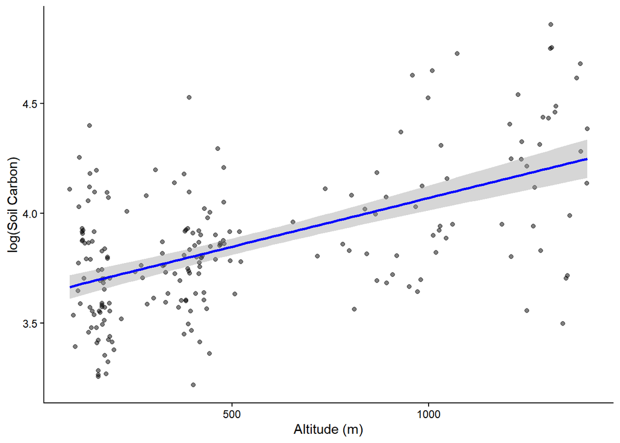

```r
ggplot(data, aes(x = altitude, y = log.soil.carbon)) +
  geom_point(alpha = 0.5) +
  geom_smooth(method = "lm", color = "blue") +
  ylab("log(Soil Carbon)") +
  xlab("Altitude (m)") +
  theme_classic()
```

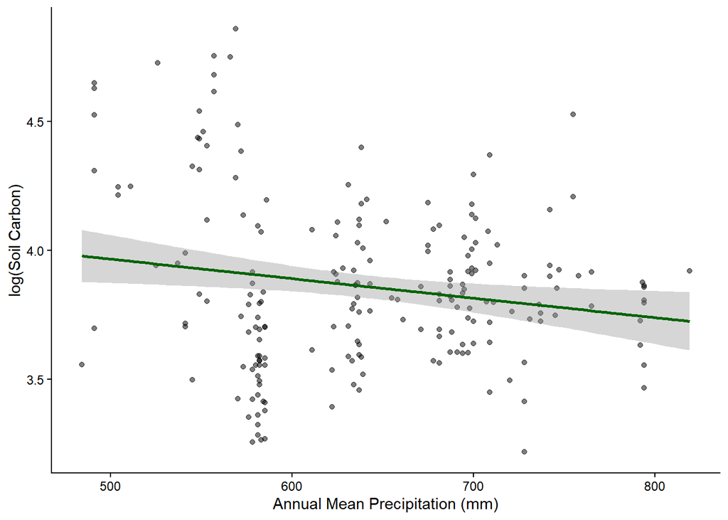

```r
ggplot(data, aes(x = annual.mean.precipitation, y = log.soil.carbon)) +
  geom_point(alpha = 0.5) +
  geom_smooth(method = "lm", color = "darkgreen") +
  ylab("log(Soil Carbon)") +
  xlab("Annual Mean Precipitation (mm)") +
  theme_classic()
```

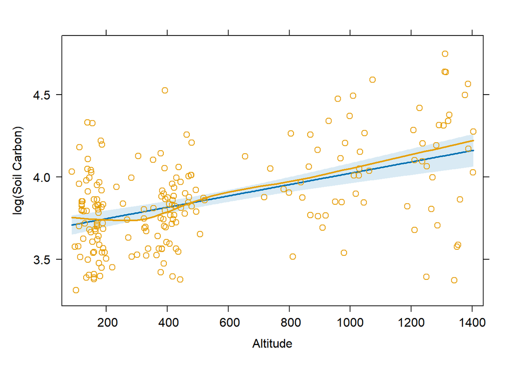

```r
#use effect

eff_alt <- effect("altitude", m_base, partial.residuals = TRUE)
plot(eff_alt,
     main = "",
     ylab = "log(Soil Carbon)",
     xlab = "Altitude")
```

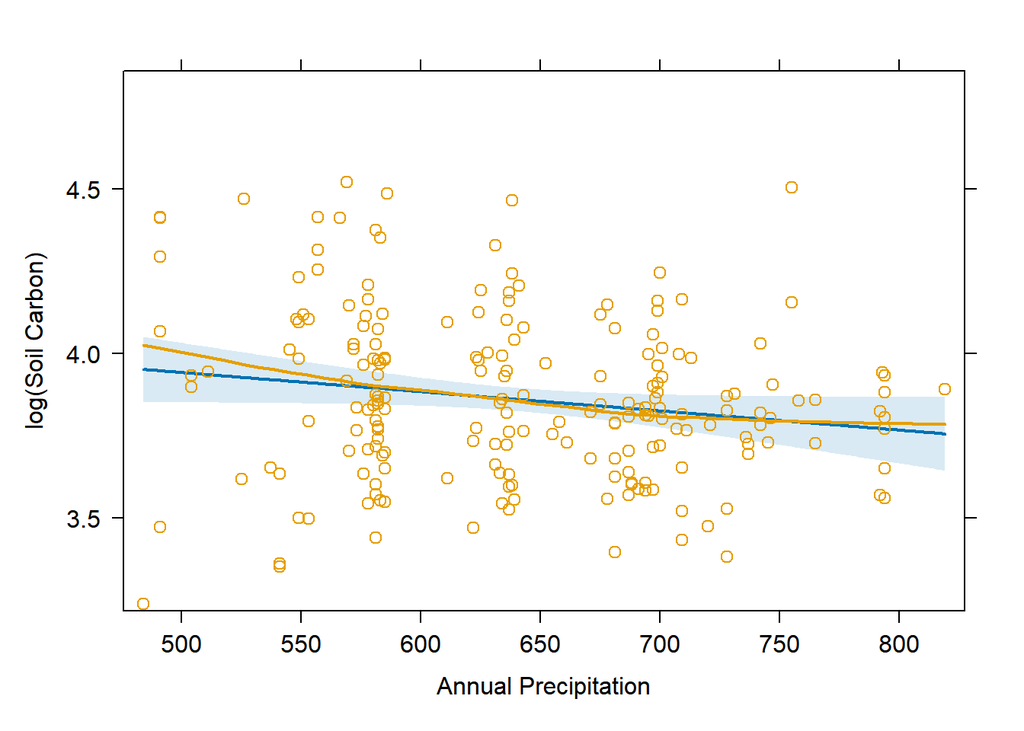

```r
eff_precip <- effect("annual.mean.precipitation", m_base, partial.residuals = TRUE)
plot(eff_precip,
     main = "",
     ylab = "log(Soil Carbon)",
     xlab = "Annual Precipitation")
```

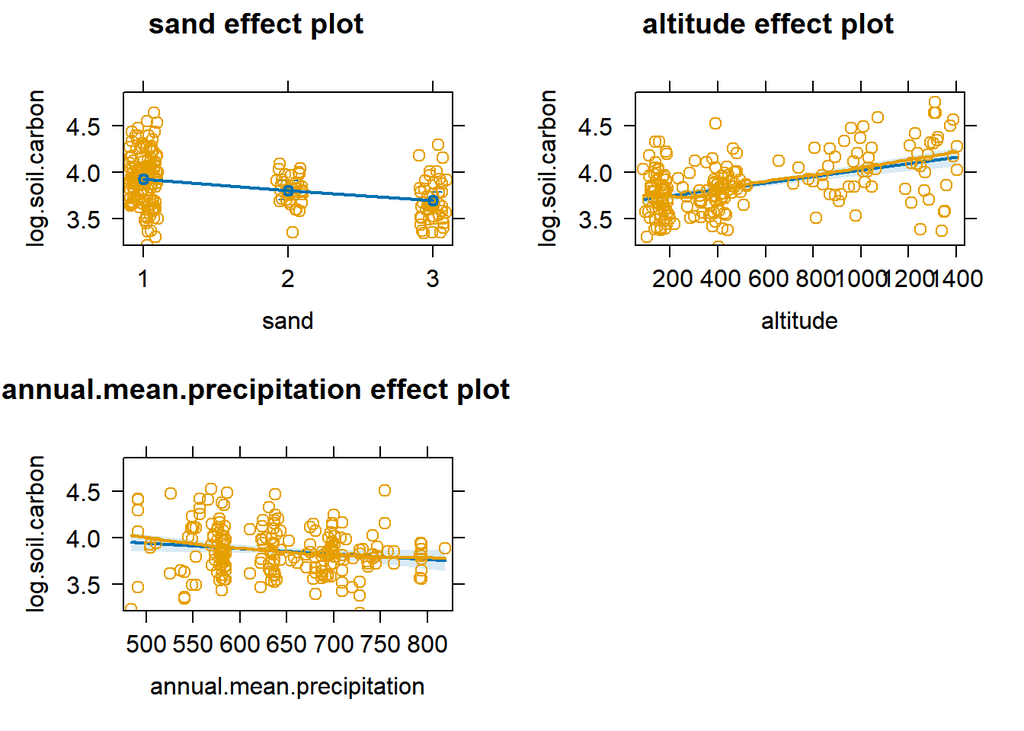

```r
eff_all <- allEffects(m_base, partial.residuals = TRUE)
plot(eff_all)
```

```r
library(emmeans)
anova_sand <- lm(log.soil.carbon ~ sand, data = data)
emmeans(anova_sand, pairwise ~ sand, adjust = "Tukey")
```

```
## $emmeans
##  sand emmean     SE  df lower.CL upper.CL
##  1      3.95 0.0262 205     3.90     4.00
##  2      3.82 0.0520 205     3.71     3.92
##  3      3.63 0.0445 205     3.54     3.71
##
## Confidence level used: 0.95
##
## $contrasts
##  contrast      estimate     SE  df t.ratio p.value
##  sand1 - sand2    0.134 0.0582 205   2.311  0.0565
##  sand1 - sand3    0.326 0.0516 205   6.305 <0.0001
##  sand2 - sand3    0.191 0.0684 205   2.793  0.0157
##
## P value adjustment: tukey method for comparing a family of 3 estimates
```

Based on the model-adjusted estimated means (emmeans), sand type had a clear effect on soil carbon stock. Soil carbon in sand3 was significantly lower than in sand1 and sand2 (sand1–sand3: p < 0.0001, sand2–sand3: p = 0.016), while the difference between sand1 and sand2 was marginally significant (p = 0.056). Overall, this suggests that sand type has a notable influence on soil carbon.

So far, the factors that had significant effects on soil carbon as single predictors were sand, altitude, and annual mean precipitation. Other factors did not show significant effects on soil carbon on their own.

For interaction effects, the following combinations will be examined:

sand × species richness

sand × precipitation

altitude × temperature

altitude × precipitation

precipitation × target species richness

```r
#intaraction between sand and target.species.richness
m_sand_rich <- lm(log.soil.carbon ~ sand*target.species.richness, data = data)
summary(m_sand_rich)
```

```
##
## Call:
## lm(formula = log.soil.carbon ~ sand * target.species.richness,
##     data = data)
##
## Residuals:
##      Min       1Q   Median       3Q      Max
## -0.73604 -0.19300 -0.04076  0.15221  0.90524
##
## Coefficients: (1 not defined because of singularities)
##                                 Estimate Std. Error t value Pr(>|t|)
## (Intercept)                     3.952791   0.050833  77.760   <2e-16 ***
## sand2                          -0.179965   0.119214  -1.510   0.1328
## sand3                          -0.311379   0.125989  -2.471   0.0143 *
## target.species.richness2        0.007854   0.065386   0.120   0.9045
## target.species.richness3       -0.020968   0.078498  -0.267   0.7897
## target.species.richness4       -0.004080   0.101666  -0.040   0.9680
## target.species.richness5       -0.092824   0.309206  -0.300   0.7643
## sand2:target.species.richness2  0.001118   0.165926   0.007   0.9946
## sand3:target.species.richness2 -0.040620   0.157227  -0.258   0.7964
## sand2:target.species.richness3  0.106281   0.159819   0.665   0.5068
## sand3:target.species.richness3 -0.064336   0.163116  -0.394   0.6937
## sand2:target.species.richness4  0.072320   0.201418   0.359   0.7199
## sand3:target.species.richness4  0.067345   0.181460   0.371   0.7109
## sand2:target.species.richness5        NA         NA      NA       NA
## sand3:target.species.richness5  0.181242   0.394221   0.460   0.6462
## ---
## Signif. codes:  0 '***' 0.001 '**' 0.01 '*' 0.05 '.' 0.1 ' ' 1
##
## Residual standard error: 0.305 on 194 degrees of freedom
## Multiple R-squared:  0.1754, Adjusted R-squared:  0.1201
## F-statistic: 3.174 on 13 and 194 DF,  p-value: 0.0002447
```

There was no interaction between sand and target species richness.

```r
#sand and annual.mean.precipitation
m_sand_precip <- lm(log.soil.carbon ~ sand*annual.mean.precipitation, data = data)
summary(m_sand_precip)
```

```
##
## Call:
## lm(formula = log.soil.carbon ~ sand * annual.mean.precipitation,
##     data = data)
##
## Residuals:
##      Min       1Q   Median       3Q      Max
## -0.69972 -0.18599 -0.00584  0.17877  0.79097
##
## Coefficients:
##                                   Estimate Std. Error t value Pr(>|t|)
## (Intercept)                      5.1818742  0.2004037  25.857  < 2e-16 ***
## sand2                           -1.7561640  0.6116250  -2.871  0.00452 **
## sand3                           -2.7051760  0.8641267  -3.131  0.00200 **
## annual.mean.precipitation       -0.0019153  0.0003095  -6.188 3.34e-09 ***
## sand2:annual.mean.precipitation  0.0024713  0.0008761   2.821  0.00527 **
## sand3:annual.mean.precipitation  0.0038644  0.0014579   2.651  0.00867 **
## ---
## Signif. codes:  0 '***' 0.001 '**' 0.01 '*' 0.05 '.' 0.1 ' ' 1
##
## Residual standard error: 0.2744 on 202 degrees of freedom
## Multiple R-squared:  0.3049, Adjusted R-squared:  0.2877
## F-statistic: 17.72 on 5 and 202 DF,  p-value: 1.506e-14
```

The effect of precipitation reduces the differences in soil carbon among the sand types.

```r
#altitude and temperature
m_alt_temp <- lm(log.soil.carbon ~ altitude*annual.mean.temperature, data = data)
summary(m_alt_temp)
```

```
##
## Call:
## lm(formula = log.soil.carbon ~ altitude * annual.mean.temperature,
##     data = data)
##
## Residuals:
##      Min       1Q   Median       3Q      Max
## -0.79315 -0.16210  0.00671  0.14768  0.75059
##
## Coefficients:
##                                    Estimate Std. Error t value Pr(>|t|)
## (Intercept)                       3.884e+00  7.129e-02  54.484  < 2e-16 ***
## altitude                         -1.394e-04  1.653e-04  -0.843 0.400117
## annual.mean.temperature          -3.706e-02  9.387e-03  -3.948 0.000108 ***
## altitude:annual.mean.temperature  7.516e-05  1.978e-05   3.800 0.000191 ***
## ---
## Signif. codes:  0 '***' 0.001 '**' 0.01 '*' 0.05 '.' 0.1 ' ' 1
##
## Residual standard error: 0.2617 on 204 degrees of freedom
## Multiple R-squared:  0.3617, Adjusted R-squared:  0.3523
## F-statistic: 38.53 on 3 and 204 DF,  p-value: < 2.2e-16
```

Altitude mitigates the decrease in soil carbon caused by higher temperatures.

```r
#altitude and annual.mean,precipitation
m_alt_precip <- lm(log.soil.carbon ~ altitude*annual.mean.precipitation, data = data)
summary(m_alt_precip)
```

```
##
## Call:
## lm(formula = log.soil.carbon ~ altitude * annual.mean.precipitation,
##     data = data)
##
## Residuals:
##      Min       1Q   Median       3Q      Max
## -0.78171 -0.17306 -0.00515  0.16458  0.69236
##
## Coefficients:
##                                      Estimate Std. Error t value Pr(>|t|)
## (Intercept)                         2.931e+00  3.573e-01   8.201 2.63e-14 ***
## altitude                            1.729e-03  4.832e-04   3.577 0.000433 ***
## annual.mean.precipitation           1.159e-03  5.738e-04   2.019 0.044752 *
## altitude:annual.mean.precipitation -2.192e-06  8.141e-07  -2.692 0.007693 **
## ---
## Signif. codes:  0 '***' 0.001 '**' 0.01 '*' 0.05 '.' 0.1 ' ' 1
##
## Residual standard error: 0.267 on 204 degrees of freedom
## Multiple R-squared:  0.3355, Adjusted R-squared:  0.3257
## F-statistic: 34.33 on 3 and 204 DF,  p-value: < 2.2e-16
```

Altitude has a negative effect on the impact of precipitation on soil carbon.

```r
m_precip_rich <- lm(log.soil.carbon ~ annual.mean.precipitation*target.species.richness, data = data)
summary(m_precip_rich)
```

```
##
## Call:
## lm(formula = log.soil.carbon ~ annual.mean.precipitation * target.species.richness,
##     data = data)
##
## Residuals:
##      Min       1Q   Median       3Q      Max
## -0.71008 -0.22796 -0.01333  0.17805  0.93408
##
## Coefficients:
##                                                      Estimate Std. Error
## (Intercept)                                         4.9752317  0.3851254
## annual.mean.precipitation                          -0.0017190  0.0006013
## target.species.richness2                           -0.5990854  0.4961188
## target.species.richness3                           -1.1515858  0.5584995
## target.species.richness4                           -1.0471981  0.6545668
## target.species.richness5                           -1.9046834  2.3105628
## annual.mean.precipitation:target.species.richness2  0.0009378  0.0007760
## annual.mean.precipitation:target.species.richness3  0.0017115  0.0008578
## annual.mean.precipitation:target.species.richness4  0.0015795  0.0010150
## annual.mean.precipitation:target.species.richness5  0.0028603  0.0037368
##                                                    t value Pr(>|t|)
## (Intercept)                                         12.918  < 2e-16 ***
## annual.mean.precipitation                           -2.859  0.00471 **
## target.species.richness2                            -1.208  0.22866
## target.species.richness3                            -2.062  0.04052 *
## target.species.richness4                            -1.600  0.11123
## target.species.richness5                            -0.824  0.41074
## annual.mean.precipitation:target.species.richness2   1.208  0.22830
## annual.mean.precipitation:target.species.richness3   1.995  0.04740 *
## annual.mean.precipitation:target.species.richness4   1.556  0.12127
## annual.mean.precipitation:target.species.richness5   0.765  0.44492
## ---
## Signif. codes:  0 '***' 0.001 '**' 0.01 '*' 0.05 '.' 0.1 ' ' 1
##
## Residual standard error: 0.3224 on 198 degrees of freedom
## Multiple R-squared:  0.05975,    Adjusted R-squared:  0.01701
## F-statistic: 1.398 on 9 and 198 DF,  p-value: 0.1911
```

There is no interaction between precipitation and target species richness.

In summary, the observed interactions among factors are as follows:

The effect of precipitation reduces the differences in soil carbon among sand types.

Altitude mitigates the decrease in soil carbon caused by higher temperatures.

Altitude has a negative effect on the impact of precipitation on soil carbon.

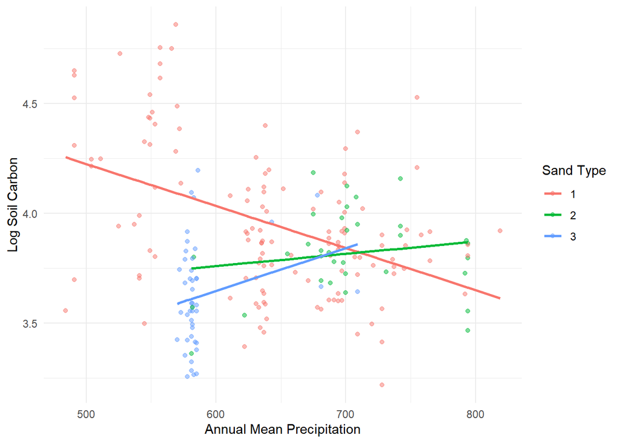

```r
library(ggplot2)


data$pred <- predict(m_sand_precip, newdata = data)


ggplot(data, aes(x = annual.mean.precipitation, y = log.soil.carbon, color = sand)) +
  geom_point(alpha = 0.5) +
  geom_line(aes(y = pred), size = 1) +
  labs(x = "Annual Mean Precipitation", y = "Log Soil Carbon", color = "Sand Type") +
  theme_minimal()
```

The annual mean precipitation shows an interesting effect in its interaction with sand type on soil carbon. Sand type had a significant impact on soil carbon (sand2: -1.76, p = 0.0045; sand3: -2.71, p = 0.0020). Additionally, precipitation reduced soil carbon in the reference sand, but this negative effect was mitigated in sand2 and sand3 due to the interaction with sand type. The overall model was significant (F = 17.72, p < 0.001) and explained approximately 30% of the variation in soil carbon (R² = 0.305).

However, soil carbon may also be influenced by country, litter layer, root biomass, and microbial biomass. Therefore, these factors should be incorporated as random effects or interaction terms, and the changes in fixed effects, as well as factors that were not significant on their own, should be re-evaluated.